# Struggles with Remote Work

## Disability

Having a disability or chronic illness had little effect on the types of struggles workers experience.

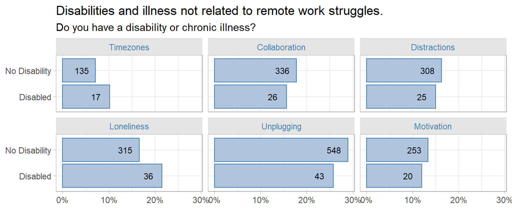

```r
buffer %>% plot_prop("disability",
                     "Disabilities and illness not related to remote work struggles.")
```

## Caregivers

Parents and caregivers were much more likely to struggle with distractions. The upside is that they were also less likely to feel lonely.

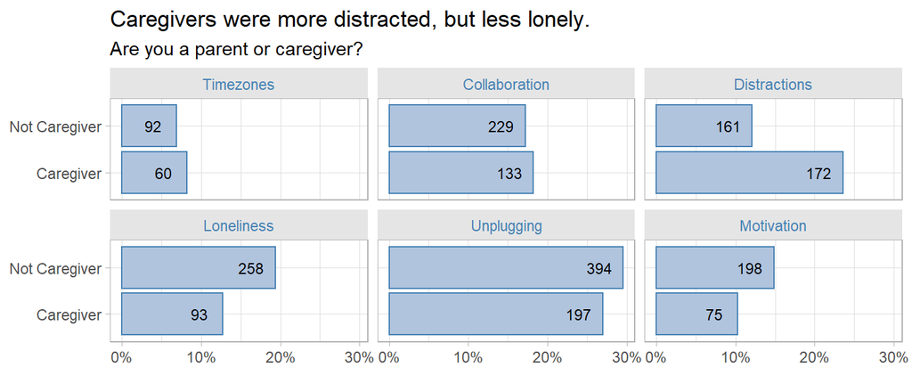

```r
buffer %>% plot_prop("caregiver",
                     "Caregivers were more distracted, but less lonely.")
```

## Full-time Employees

Smaller organizations struggle with distractions, motivation; bigger with unplugging

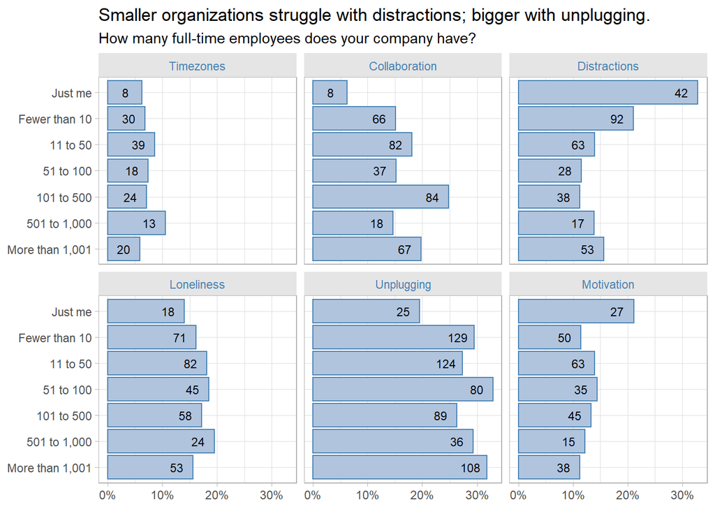

```r
buffer %>% plot_prop("fte",
                     "Smaller organizations struggle with distractions; bigger with unplugging.")
```

## Industry

Struggles are farely common across industries. Government predictably does not deal with time zone issues.

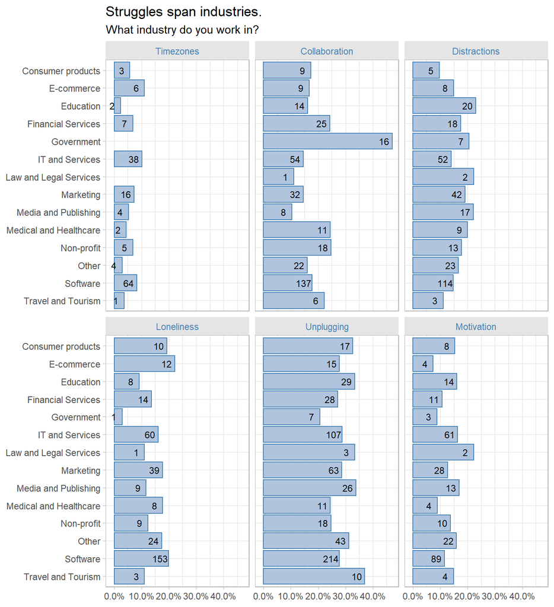

```r
buffer %>% plot_prop("industry",
                     "Struggles span industries.")
```

## Role

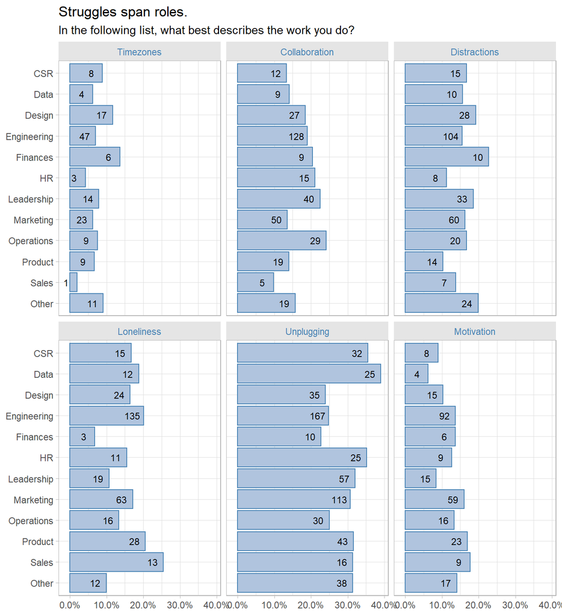

```r
buffer %>% plot_prop("role",
                     "Struggles span roles.")
```

## Conclusions

What factors are likely to lead to each of the struggles? The table below shows the distribution of struggles for each group of each variable. Struggles that map strongly, which I define as >25% to any struggle are colored blue. Unfortunately, most factor levels map strongly only to *Unplugging*.

```r
struggle_prop <- function(fctr) {
  fctr_var <- ensym(fctr)
  buffer %>%
    filter(struggle != "Other") %>%
    count(Level = !!fctr_var, struggle) %>%
    group_by(Level) %>%
    mutate(Factor = fctr, pct = n / sum(n)) %>%
    pivot_wider(id_cols = c(Factor, Level), names_from = struggle, values_from = pct) %>%
    mutate(Level = as.character(Level))
}

smry_mtrx <- bind_rows(
  struggle_prop("race"),
  struggle_prop("work_exp"),
  struggle_prop("remote_exp"),
  struggle_prop("emp_type"),
  struggle_prop("pct_remote"),
  struggle_prop("covid"),
  struggle_prop("disability"),
  struggle_prop("caregiver"),
  struggle_prop("fte"),
  struggle_prop("industry"),
  struggle_prop("role")
) %>%
  pivot_longer(cols = Timezones:Motivation, names_to = "struggle") %>%
  mutate(color = if_else(value > 1/4, "dodgerblue", "darkgray"))

color_wide <- smry_mtrx %>%
  pivot_wider(id_cols = c(Factor, Level), names_from = struggle, values_from = color) %>%
  as.matrix()

smry_mtrx %>%
  mutate(value = value * 100) %>%
  pivot_wider(id_cols = c(Factor, Level), names_from = struggle, values_from = value) %>%
  flextable::as_grouped_data(groups = "Factor") %>%
  flextable::flextable() %>%
  flextable::color(i = ~ is.na(Factor), j = 3:8, color = color_wide[, 3:8]) %>%
  flextable::bg(i = ~ !is.na(Factor), bg = "lightgray") %>%
  flextable::colformat_double(j = 3:8, digits = 0, suffix = "%") %>%
  flextable::border(j = 2, border.right = officer::fp_border(color = "lightgray")) %>%
  flextable::autofit() %>%
  flextable::bold(j = 1:2) %>%
  flextable::fontsize(size = 10) %>%
  flextable::autofit()
```

| Factor | Level | Timezones | Collaboration | Distractions | Loneliness | Unplugging | Motivation |
| --- | --- | --- | --- | --- | --- | --- | --- |
| race |  |  |  |  |  |  |  |
|  | White | 7% | 19% | 15% | 17% | 28% | 14% |
|  | Black | 12% | 9% | 27% | 14% | 25% | 12% |
|  | Hispanic | 5% | 18% | 17% | 16% | 33% | 12% |
|  | Asian | 9% | 14% | 22% | 15% | 30% | 10% |
|  | Multiracial | 7% | 14% | 17% | 24% | 25% | 14% |
|  | Other/Unk | 12% | 10% | 16% | 16% | 34% | 12% |
| work_exp |  |  |  |  |  |  |  |
|  | Less than six months | 7% | 15% | 22% | 11% | 20% | 26% |
|  | 6 months - 11 months | 8% | 12% | 14% | 24% | 27% | 16% |
|  | 1 year - 4 years | 5% | 17% | 14% | 22% | 25% | 17% |
|  | 5 years - 9 years | 7% | 16% | 17% | 20% | 26% | 14% |
|  | 10 years - 14 years | 9% | 16% | 16% | 16% | 32% | 10% |
|  | 15 years - 19 years | 8% | 21% | 17% | 14% | 28% | 11% |
|  | More than 20 years | 8% | 20% | 16% | 11% | 34% | 11% |
| remote_exp |  |  |  |  |  |  |  |
|  | Less than six months | 5% | 22% | 13% | 15% | 26% | 20% |
|  | 6 months to 11 months | 3% | 20% | 15% | 17% | 28% | 16% |
|  | 1 year to 4 years | 9% | 15% | 17% | 19% | 28% | 11% |
|  | 5 years - 9 years | 10% | 16% | 20% | 14% | 29% | 11% |
|  | More than 10 years | 15% | 16% | 10% | 15% | 37% | 7% |
| emp_type |  |  |  |  |  |  |  |
|  | Business Owner | 9% | 14% | 21% | 18% | 29% | 9% |
|  | Employee | 7% | 19% | 14% | 17% | 29% | 13% |
|  | Self-Employed | 8% | 13% | 23% | 17% | 25% | 15% |
| pct_remote |  |  |  |  |  |  |  |
|  | 1 to 25% | 10% | 15% | 15% | 17% | 30% | 13% |
|  | 26 to 50% | 3% | 15% | 19% | 20% | 24% | 18% |
|  | 51 to 75% | 5% | 25% | 14% | 14% | 30% | 12% |
|  | 76 to 99% | 6% | 25% | 12% | 15% | 30% | 12% |
|  | 100% | 8% | 14% | 18% | 18% | 28% | 13% |
| covid |  |  |  |  |  |  |  |
|  | Not Related | 11% | 14% | 17% | 18% | 28% | 12% |
|  | COVID-Related | 3% | 22% | 15% | 16% | 29% | 15% |
| disability |  |  |  |  |  |  |  |
|  | No Disability | 7% | 18% | 16% | 17% | 29% | 13% |
|  | Disabled | 10% | 16% | 15% | 22% | 26% | 12% |
| caregiver |  |  |  |  |  |  |  |
|  | Not Caregiver | 7% | 17% | 12% | 19% | 30% | 15% |
|  | Caregiver | 8% | 18% | 24% | 13% | 27% | 10% |
| fte |  |  |  |  |  |  |  |
|  | Just me | 6% | 6% | 33% | 14% | 20% | 21% |
|  | Fewer than 10 | 7% | 15% | 21% | 16% | 29% | 11% |
|  | 11 to 50 | 9% | 18% | 14% | 18% | 27% | 14% |
|  | 51 to 100 | 7% | 15% | 12% | 19% | 33% | 14% |
|  | 101 to 500 | 7% | 25% | 11% | 17% | 26% | 13% |
|  | 501 to 1,000 | 11% | 15% | 14% | 20% | 29% | 12% |
|  | More than 1,001 | 6% | 20% | 16% | 16% | 32% | 11% |
| industry |  |  |  |  |  |  |  |
|  | Consumer products | 6% | 17% | 10% | 19% | 33% | 15% |
|  | E-commerce | 11% | 17% | 15% | 22% | 28% | 7% |
|  | Education | 2% | 16% | 23% | 9% | 33% | 16% |
|  | Financial Services | 7% | 24% | 17% | 14% | 27% | 11% |
|  | Government |  | 47% | 21% | 3% | 21% | 9% |
|  | IT and Services | 10% | 15% | 14% | 16% | 29% | 16% |
|  | Law and Legal Services |  | 11% | 22% | 11% | 33% | 22% |
|  | Marketing | 7% | 15% | 19% | 18% | 29% | 13% |
|  | Media and Publishing | 5% | 10% | 22% | 12% | 34% | 17% |
|  | Medical and Healthcare | 4% | 24% | 20% | 18% | 24% | 9% |
|  | Non-profit | 7% | 25% | 18% | 12% | 25% | 14% |
|  | Other | 3% | 16% | 17% | 17% | 31% | 16% |
|  | Software | 8% | 18% | 15% | 20% | 28% | 12% |
|  | Travel and Tourism | 4% | 22% | 11% | 11% | 37% | 15% |
| role |  |  |  |  |  |  |  |
|  | CSR | 9% | 13% | 17% | 17% | 36% | 9% |
|  | Data | 6% | 14% | 16% | 19% | 39% | 6% |
|  | Design | 12% | 18% | 19% | 16% | 24% | 10% |
|  | Engineering | 7% | 19% | 15% | 20% | 25% | 14% |
|  | Finances | 14% | 20% | 23% | 7% | 23% | 14% |
|  | HR | 4% | 21% | 11% | 15% | 35% | 13% |
|  | Leadership | 8% | 22% | 19% | 11% | 32% | 8% |
|  | Marketing | 6% | 14% | 16% | 17% | 31% | 16% |
|  | Operations | 8% | 24% | 17% | 13% | 25% | 13% |
|  | Product | 7% | 14% | 10% | 21% | 32% | 17% |
|  | Sales | 2% | 10% | 14% | 25% | 31% | 18% |
|  | Other | 9% | 16% | 20% | 10% | 31% | 14% |